# Seminar 1

Human Prion Disease - Statistical Analysis

Author

CM2018 Group

Published

September 19, 2026

## Before rendering

Keep `T1_data.csv`, `T3_data.csv` and `T4_data.csv` in the same working directory. Task 2 also requires `CM2018rpackage`. The analyses are connected: Task 2 uses `t1`, while Task 4 uses `t3`.

# Task 1 - Biomarker investigation

**Research focus:** Do plasma NfL and Tau differ between Healthy and Disease participants?

## 1.1 Import and check the data

Validate the imported dataset before making statistical claims.

```r
# 1.1 IMPORT AND CHECK THE DATA

t1 <- read.csv("T1_data.csv")

t1$Group <- factor(
  t1$Group,
  levels = c("Healthy", "Disease")
)

# Healthy is the reference group in lm() and appears first in plots.

str(t1)
```

```
'data.frame':   40 obs. of  4 variables:
 $ ID   : int  1 2 3 4 5 6 7 8 9 10 ...
 $ Group: Factor w/ 2 levels "Healthy","Disease": 1 1 1 1 1 1 1 1 1 1 ...
 $ NfL  : num  34.4 16.7 15.9 21.2 86.5 ...
 $ Tau  : num  0.61 3.44 1.75 0.7 1.73 0.99 0.66 1.37 3.8 0.54 ...
```

```r
head(t1)
```

```
  ID   Group   NfL  Tau
1  1 Healthy 34.39 0.61
2  2 Healthy 16.71 3.44
3  3 Healthy 15.88 1.75
4  4 Healthy 21.17 0.70
5  5 Healthy 86.46 1.73
6  6 Healthy 34.40 0.99
```

```r
summary(t1)
```

```
       ID            Group         NfL              Tau
 Min.   : 1.00   Healthy:25   Min.   :  9.03   Min.   :0.3400
 1st Qu.:10.75   Disease:15   1st Qu.: 20.70   1st Qu.:0.8375
 Median :20.50                Median : 32.65   Median :1.6800
 Mean   :20.50                Mean   : 42.66   Mean   :2.1580
 3rd Qu.:30.25                3rd Qu.: 48.83   3rd Qu.:2.7400
 Max.   :40.00                Max.   :148.59   Max.   :8.6200
```

```r
table(t1$Group)
```

```
Healthy Disease
     25      15
```

```r
# OUTPUT: Healthy = 25; Disease = 15.

colSums(is.na(t1))
```

```
   ID Group   NfL   Tau
    0     0     0     0
```

```r
# OUTPUT: no missing values.

anyDuplicated(t1$ID)
```

```
[1] 0
```

```r
# OUTPUT: 0, meaning no repeated participant IDs.

any(t1$NfL <= 0)
```

```
[1] FALSE
```

```r
any(t1$Tau <= 0)
```

```
[1] FALSE
```

```r
# OUTPUT: FALSE for both biomarkers.
# All values are positive, so log() can be applied.
#
# Unequal group sizes alone do not establish independence.
# The assignment mentions matching, but its structure is not documented.
```

## 1.2 Descriptive statistics

Describe location and spread on both arithmetic and multiplicative scales.

```r
# 1.2 DESCRIPTIVE STATISTICS

aggregate(cbind(NfL, Tau) ~ Group, data = t1, FUN = mean)
```

```
    Group     NfL      Tau
1 Healthy 32.9196 1.689200
2 Disease 58.8940 2.939333
```

```r
# Arithmetic means, in pg/mL:
# Group        NfL       Tau
# Healthy    32.9196    1.6892
# Disease    58.8940    2.9393

aggregate(cbind(NfL, Tau) ~ Group, data = t1, FUN = sd)
```

```
    Group      NfL      Tau
1 Healthy 22.76974 1.421029
2 Disease 40.48328 2.296328
```

```r
# Standard deviations, in pg/mL:
# Group        NfL       Tau
# Healthy    22.7697    1.4210
# Disease    40.4833    2.2963
#
# SD describes variation between participants.
# It is different from the standard error of an estimated mean.

aggregate(cbind(NfL, Tau) ~ Group, data = t1, FUN = median)
```

```
    Group   NfL  Tau
1 Healthy 27.02 1.22
2 Disease 40.83 2.50
```

```r
# Medians, in pg/mL:
# Group        NfL       Tau
# Healthy     27.02      1.22
# Disease     40.83      2.50

aggregate(
  cbind(NfL, Tau) ~ Group,
  data = t1,
  FUN = function(x) exp(mean(log(x)))
)
```

```
    Group      NfL      Tau
1 Healthy 27.09016 1.272399
2 Disease 46.46914 2.188415
```

```r
# Geometric means, in pg/mL:
# Group        NfL       Tau
# Healthy    27.0902    1.2724
# Disease    46.4691    2.1884
#
# The geometric mean is exp(the mean of the logarithms).
# For values 10, 20 and 40:
# arithmetic mean = 23.33; geometric mean = 20.
#
# The log transformation expresses proportional changes as differences.
# Doubling any value adds log(2).
# Exponentiating a difference between mean logs gives a geometric-mean ratio.
#
# "~ Group" means that the calculations are performed separately by group.
# cbind(NfL, Tau) allows both biomarkers to be summarised together.
```

## 1.3 Compare original and log scales

Compare the original and log scales while retaining every participant.

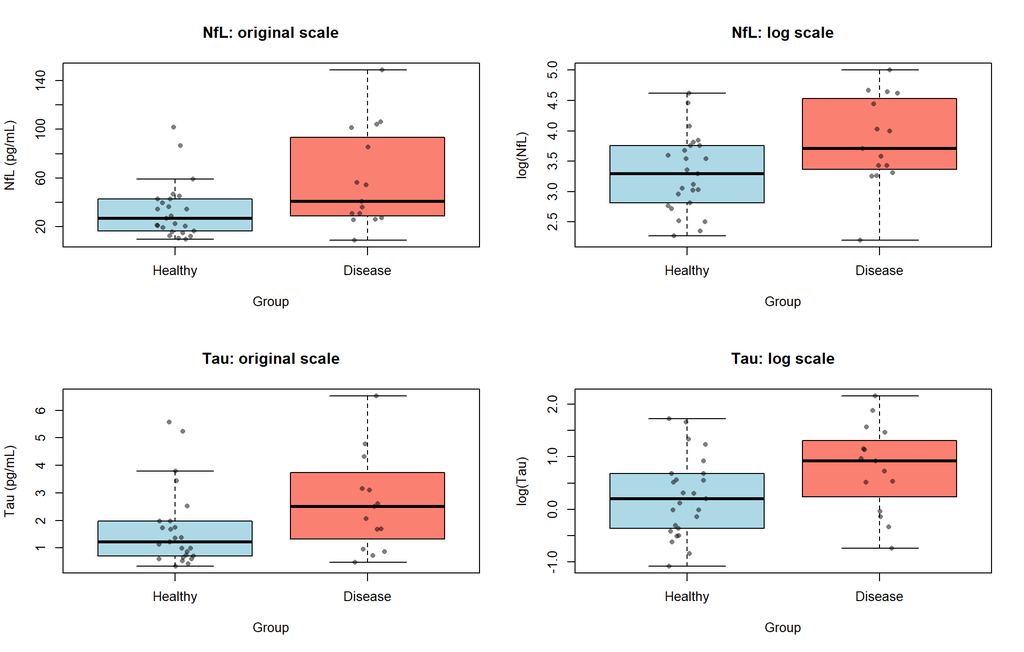

```r
# 1.3 COMPARE ORIGINAL AND LOG SCALES

par(mfrow = c(2, 2))

boxplot(
  NfL ~ Group, data = t1,
  main = "NfL: original scale",
  ylab = "NfL (pg/mL)",
  col = c("lightblue", "salmon"),
  outline = FALSE
)

stripchart(
  NfL ~ Group, data = t1,
  vertical = TRUE, method = "jitter",
  add = TRUE, pch = 16,
  col = rgb(0, 0, 0, 0.5)
)

boxplot(
  log(NfL) ~ Group, data = t1,
  main = "NfL: log scale",
  ylab = "log(NfL)",
  col = c("lightblue", "salmon"),
  outline = FALSE
)

stripchart(
  log(NfL) ~ Group, data = t1,
  vertical = TRUE, method = "jitter",
  add = TRUE, pch = 16,
  col = rgb(0, 0, 0, 0.5)
)

boxplot(
  Tau ~ Group, data = t1,
  main = "Tau: original scale",
  ylab = "Tau (pg/mL)",
  col = c("lightblue", "salmon"),
  outline = FALSE
)

stripchart(
  Tau ~ Group, data = t1,
  vertical = TRUE, method = "jitter",
  add = TRUE, pch = 16,
  col = rgb(0, 0, 0, 0.5)
)

boxplot(
  log(Tau) ~ Group, data = t1,
  main = "Tau: log scale",
  ylab = "log(Tau)",
  col = c("lightblue", "salmon"),
  outline = FALSE
)

stripchart(
  log(Tau) ~ Group, data = t1,
  vertical = TRUE, method = "jitter",
  add = TRUE, pch = 16,
  col = rgb(0, 0, 0, 0.5)
)
```

```r
par(mfrow = c(1, 1))

# Each point is one participant.
# The line inside the box is the median.
# The box contains the middle 50% of observations; it is not a confidence interval.
# outline = FALSE avoids drawing outlier points twice.
# Those observations are still shown by stripchart() and retained in the analysis.
#
# INTERPRETATION:
# The original distributions are right-skewed.
# The log transformation compresses high values and improves symmetry.
# Disease tends to have higher values, but the groups overlap.
```

## 1.4 Residual Q-Q plots

Use model residuals to assess whether the log scale better supports the normal approximation.

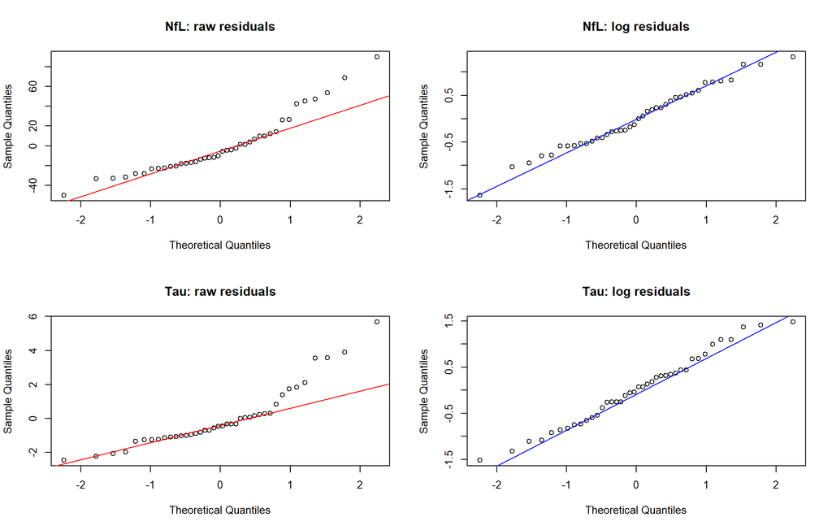

```r
# 1.4 RESIDUAL Q-Q PLOTS

nfl_raw_model <- lm(NfL ~ Group, data = t1)
nfl_log_model <- lm(log(NfL) ~ Group, data = t1)

tau_raw_model <- lm(Tau ~ Group, data = t1)
tau_log_model <- lm(log(Tau) ~ Group, data = t1)

par(mfrow = c(2, 2))

qqnorm(residuals(nfl_raw_model), main = "NfL: raw residuals")
qqline(residuals(nfl_raw_model), col = "red")

qqnorm(residuals(nfl_log_model), main = "NfL: log residuals")
qqline(residuals(nfl_log_model), col = "blue")

qqnorm(residuals(tau_raw_model), main = "Tau: raw residuals")
qqline(residuals(tau_raw_model), col = "red")

qqnorm(residuals(tau_log_model), main = "Tau: log residuals")
qqline(residuals(tau_log_model), col = "blue")
```

```r
par(mfrow = c(1, 1))

# Residual = observed value - fitted value.
# With Group as the only predictor, the fitted value is the group mean
# on the scale used in the model.
#
# The Q-Q plot compares ordered residuals with normal-distribution quantiles.
# A roughly straight pattern supports approximate normality.
# Log-scale residuals follow the reference line more closely here.
#
# A Q-Q plot does not prove normality or test the Healthy-Disease difference.
# It also does not check independence or equality of variances.
#
# These lm() models are used for diagnostics.
# Ordinary lm() coefficient tests assume a common residual variance.
# The Welch tests below allow unequal variances.
```

## 1.5 Welch test for NfL

Test NfL and express the mean-log difference as a Disease/Healthy geometric-mean ratio.

```r
# 1.5 WELCH TEST FOR NfL

nfl_disease <- log(t1$NfL[t1$Group == "Disease"])
nfl_healthy <- log(t1$NfL[t1$Group == "Healthy"])

nfl_test <- t.test(
  nfl_disease,
  nfl_healthy,
  alternative = "two.sided",
  var.equal = FALSE
)

nfl_test
```

```
    Welch Two Sample t-test

data:  nfl_disease and nfl_healthy
t = 2.3473, df = 25.721, p-value = 0.02689
alternative hypothesis: true difference in means is not equal to 0
95 percent confidence interval:
 0.06683087 1.01240471
sample estimates:
mean of x mean of y
 3.838789  3.299171
```

```r
nfl_ratio <- exp(nfl_test$estimate[1] - nfl_test$estimate[2])
nfl_ratio_CI <- exp(nfl_test$conf.int)

nfl_ratio
```

```
mean of x
 1.715351
```

```r
nfl_ratio_CI
```

```
[1] 1.069115 2.752211
attr(,"conf.level")
[1] 0.95
```

```r
nfl_test$p.value
```

```
[1] 0.02688828
```

```r
# H0: equal population means of log(NfL).
# Equivalently, the Disease/Healthy geometric-mean ratio equals 1.
#
# Disease is the first argument, so the difference is Disease - Healthy.
# var.equal = FALSE selects Welch's test.
# It does not test whether the variances are equal.
#
# KEY OUTPUTS:
# t = 2.3473; df = 25.7209; p = 0.0268883.
# Difference in mean logs = 0.539618.
# Disease/Healthy geometric-mean ratio = 1.715351.
# Individual 95% CI for the ratio = [1.069115, 2.752211].
#
# REPORT SENTENCE:
# "Geometric-mean NfL was estimated to be 71.5% higher in Disease than Healthy
# participants (ratio 1.715, unadjusted 95% CI 1.069-2.752; Welch p = 0.027)."
```

## 1.6 Welch test for Tau

Repeat the same pre-defined comparison for Tau.

```r
# 1.6 WELCH TEST FOR TAU

tau_disease <- log(t1$Tau[t1$Group == "Disease"])
tau_healthy <- log(t1$Tau[t1$Group == "Healthy"])

tau_test <- t.test(
  tau_disease,
  tau_healthy,
  alternative = "two.sided",
  var.equal = FALSE
)

tau_ratio <- exp(tau_test$estimate[1] - tau_test$estimate[2])
tau_ratio_CI <- exp(tau_test$conf.int)

tau_test
```

```
    Welch Two Sample t-test

data:  tau_disease and tau_healthy
t = 2.0689, df = 27.359, p-value = 0.04812
alternative hypothesis: true difference in means is not equal to 0
95 percent confidence interval:
 0.004808277 1.079738238
sample estimates:
mean of x mean of y
0.7831777 0.2409044
```

```r
tau_ratio
```

```
mean of x
 1.719912
```

```r
tau_ratio_CI
```

```
[1] 1.004820 2.943909
attr(,"conf.level")
[1] 0.95
```

```r
tau_test$p.value
```

```
[1] 0.04812176
```

```r
# KEY OUTPUTS:
# t = 2.0689; df = 27.3590; p = 0.0481218.
# Disease/Healthy geometric-mean ratio = 1.719912.
# Individual 95% CI = [1.004820, 2.943909].
#
# REPORT SENTENCE:
# "Geometric-mean Tau was estimated to be 72.0% higher in Disease than Healthy
# participants (ratio 1.720, unadjusted 95% CI 1.005-2.944; Welch p = 0.048)."
#
# The interval is wide and its lower limit is very close to 1.
# Avoid rounding that lower limit to 1.00 when discussing significance.
#
# A p-value is not the probability that H0 is true.
# It describes how unusual the observed test result would be under H0
# and the assumptions of the test.
```

## 1.7 Consider the two biomarkers together

Account for analysing two biomarkers and state the exploratory conclusion.

```r
# 1.7 CONSIDER THE TWO BIOMARKERS TOGETHER

t1_p_values <- c(NfL = nfl_test$p.value, Tau = tau_test$p.value)

p.adjust(t1_p_values, method = "holm")
```

```
       NfL        Tau
0.05377656 0.05377656
```

```r
# OUTPUT: approximately 0.0537766 for both biomarkers.
#
# Both individual tests have p < 0.05.
# After Holm adjustment for the two tests, neither has adjusted p < 0.05.
# This does not prove equality or absence of an association.
# The individual confidence intervals above are not adjusted for multiplicity.
#
# FINAL TASK 1 STATEMENT:
# "Both biomarkers had higher estimated geometric means in Disease.
# However, both Holm-adjusted p-values were approximately 0.054.
# The analysis is exploratory, and the small Disease sample, wide confidence
# intervals and undocumented matching limit the conclusions.
# These comparisons do not establish diagnostic accuracy or causation."


# ============================================================================
```

**Key conclusion:** Both biomarkers had higher estimated geometric means in Disease. The Disease/Healthy ratios were 1.715 for NfL and 1.720 for Tau. Both individual p-values were below 0.05, but both Holm-adjusted p-values were approximately 0.054. The evidence is exploratory and limited by the small Disease sample and undocumented matching.

# Task 2 - Clinical study

**Research focus:** How many patients are needed to detect a 20% reduction in geometric-mean NfL?

## 2.1 Calculate the sample size

Use the Task 1 Disease-group variability to plan a two-arm trial.

```r
# 2.1 CALCULATE THE SAMPLE SIZE

sd_log <- sd(log(t1$NfL[t1$Group == "Disease"]))
sd_log
```

```
[1] 0.745827
```

```r
# OUTPUT: 0.745827.
# Use Disease participants because the new trial includes patients in both arms.
#
# A 20% reduction means GM_Treatment / GM_Control = 0.80.
# For example, reducing a geometric mean from 50 to 40:
# log(40) - log(50) = log(0.80) = approximately -0.22314.

sample_size <- power.t.test(
  delta = abs(log(0.80)),
  sd = sd_log,
  sig.level = 0.05,
  power = 0.80,
  type = "two.sample",
  alternative = "two.sided"
)

sample_size
```

```
     Two-sample t test power calculation

              n = 176.3314
          delta = 0.2231436
             sd = 0.745827
      sig.level = 0.05
          power = 0.8
    alternative = two.sided

NOTE: n is number in *each* group
```

```r
n_per_arm <- ceiling(sample_size$n)
total_n <- 2 * n_per_arm

n_per_arm
```

```
[1] 177
```

```r
total_n
```

```
[1] 354
```

```r
# OUTPUT: approximately 176.33 per group.
# Round upwards to 177 per group: 354 participants in total.
#
# abs() uses the magnitude of the log difference.
# ceiling() rounds upwards to a whole number of participants.
#
# Alpha = 0.05 controls false positives under the null hypothesis.
# Power = 0.80 means about an 80% probability of detecting a difference when
# the true reduction is 20% and the planning assumptions are correct.
# It is not an 80% probability that the treatment works.
#
# power.t.test() assumes a common SD for independent groups.
# This is an approximate planning calculation for the later Welch analysis.
# The SD estimate comes from only 15 patients and is therefore uncertain.
# The required 354 participants must have usable outcomes; losses would
# require additional recruitment.
#
# REPORT SENTENCE:
# "Using the Disease-group SD of log(NfL), a two-sided significance level
# of 5% and 80% power, we recommend 177 evaluable participants per arm
# to detect a 20% reduction in geometric-mean NfL."
```

## 2.2 Specify the analysis plan before generating data

Fix the hypotheses, analysis scale and reporting strategy before generating data.

```r
# 2.2 SPECIFY THE ANALYSIS PLAN BEFORE GENERATING DATA

# Outcome: NfL at three months.
# Groups: Treatment and Control, assumed independent.
# Identified matched pairs are not supplied.
# Primary analysis: two-sided Welch t-test on log(NfL).
# Significance level: 0.05.
# H0: GM_Treatment / GM_Control = 1.
# H1: GM_Treatment / GM_Control differs from 1.
# Report: geometric-mean ratio, 95% CI and p-value.
#
# The target ratio of 0.80 is used for planning.
# The null hypothesis concerns a ratio of 1, meaning no difference.
#
# Check log-scale distributions and Q-Q plots within each arm.
# Report missing outcomes by arm and analyse available valid measurements.
# Acknowledge possible bias from missing outcomes.
# Investigate data errors, but do not remove valid observations merely
# because they look unusual.
#
# If assumptions fail seriously, report this and label any alternative
# analysis as a sensitivity analysis.
# Do not choose a test simply because it produces a smaller p-value.
#
# There is one primary outcome and one comparison, so no multiplicity
# correction is needed for the primary analysis.
```

## 2.3 Recruitment feasibility

Translate annual disease incidence into an approximate recruitment timeline.

```r
# 2.3 RECRUITMENT FEASIBILITY

# Population: 10 million.
# Incidence: 1-2 cases per million per year.
# This gives 10-20 new cases per year.
#
# If 20-80% meet the inclusion criteria:
# least favourable extreme = 10 * 0.20 = 2 eligible patients/year.
# most favourable extreme = 20 * 0.80 = 16 eligible patients/year.

eligible_per_year <- c(2, 16)
years_to_recruit <- total_n / eligible_per_year

years_to_recruit
```

```
[1] 177.000  22.125
```

```r
# OUTPUT: 177 years at 2/year; 22.125 years at 16/year.
#
# This assumes that all eligible patients participate and have usable outcomes.
# Add three months of follow-up after the last participant is enrolled.
#
# REPORT SENTENCE:
# "Recruitment would take approximately 22-177 years at a single centre
# under the stated assumptions. The proposed single-centre study is unlikely
# to be feasible; recruitment across several regions would be needed."
```

## 2.4 Generate one trial

Generate one reproducible trial at the recommended sample size.

```r
# 2.4 GENERATE ONE TRIAL

library(CM2018rpackage)

# If hpd_trial_data() is unavailable, update the course package once:
# install.packages("devtools")
# devtools::install_github("adamdarwichkth/CM2018rpackage")
# Restart R after updating.

set.seed(20260910)
trial <- hpd_trial_data(n_per_arm)

head(trial)
```

```
  ID Group    NfL
1  1     0 40.679
2  2     0 16.723
3  3     0  9.963
4  4     0 32.692
5  5     0 12.462
6  6     0 61.515
```

```r
table(trial$Group)
```

```
  0   1
177 177
```

```r
colSums(is.na(trial))
```

```
   ID Group   NfL
    0     0     0
```

```r
# OUTPUT: 177 in Group 0 (Control) and 177 in Group 1 (Treatment).
# The example contains no missing outcomes.
#
# The generator restarts ID numbering within each arm.
# These repeated labels do not identify matched patient pairs.
#
# set.seed() makes the example reproducible with the same generator version.

trial$Group <- factor(
  trial$Group,
  levels = c(0, 1),
  labels = c("Control", "Treatment")
)
```

## 2.5 Apply the pre-specified analysis

Apply the pre-specified log-scale Welch analysis to the generated trial.

```r
# 2.5 APPLY THE PRE-SPECIFIED ANALYSIS

treatment <- log(trial$NfL[trial$Group == "Treatment"])
control <- log(trial$NfL[trial$Group == "Control"])

trial_test <- t.test(
  treatment,
  control,
  alternative = "two.sided",
  var.equal = FALSE
)

trial_test
```

```
    Welch Two Sample t-test

data:  treatment and control
t = -5.6956, df = 351.36, p-value = 2.6e-08
alternative hypothesis: true difference in means is not equal to 0
95 percent confidence interval:
 -0.3877069 -0.1886777
sample estimates:
mean of x mean of y
 3.093463  3.381655
```

```r
trial_ratio <- exp(trial_test$estimate[1] - trial_test$estimate[2])
trial_ratio_CI <- exp(trial_test$conf.int)

trial_ratio
```

```
mean of x
0.7496175
```

```r
trial_ratio_CI
```

```
[1] 0.6786112 0.8280534
attr(,"conf.level")
[1] 0.95
```

```r
trial_test$p.value
```

```
[1] 2.600142e-08
```

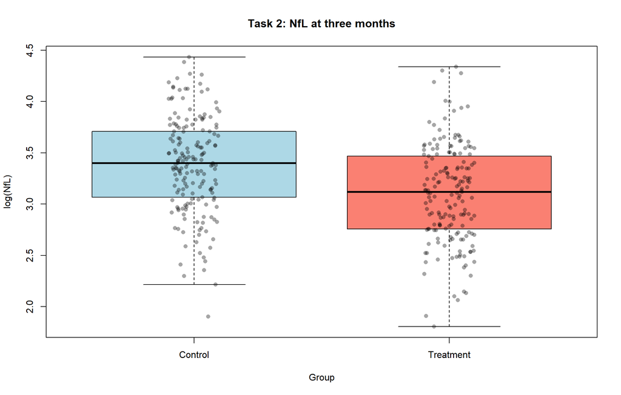

```r
# OUTPUT for the previously checked generator and seed:
# Treatment/Control ratio = 0.749617.
# 95% CI = [0.678611, 0.828053].
# Welch p = 2.60014e-08.
#
# (1 - ratio) * 100 gives the estimated percentage reduction: about 25.0%.
# The CI corresponds to approximately 17.2% to 32.1% lower NfL.
#
# REPORT SENTENCE:
# "In the simulated trial, geometric-mean NfL was approximately 25% lower
# in Treatment than Control (ratio 0.750, 95% CI 0.679-0.828; p < 0.001)."
#
# These are simulated results, not observations from an actual clinical trial.

par(mfrow = c(1, 1))

boxplot(
  log(NfL) ~ Group, data = trial,
  outline = FALSE,
  col = c("lightblue", "salmon"),
  ylab = "log(NfL)",
  main = "Task 2: NfL at three months"
)

stripchart(
  log(NfL) ~ Group, data = trial,
  vertical = TRUE, method = "jitter",
  add = TRUE, pch = 16,
  col = rgb(0, 0, 0, 0.35)
)
```

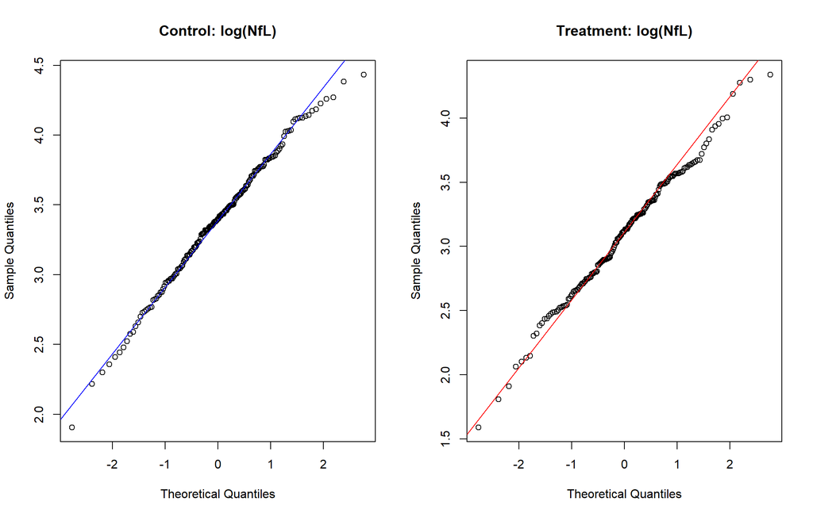

```r
par(mfrow = c(1, 2))

qqnorm(control, main = "Control: log(NfL)")
qqline(control, col = "blue")

qqnorm(treatment, main = "Treatment: log(NfL)")
qqline(treatment, col = "red")
```

```r
par(mfrow = c(1, 1))

# Roughly straight Q-Q patterns support the normal approximation on the log scale.
# They do not test the treatment difference or establish independence.
```

## 2.6 Repeat the study

Repeat the trial to demonstrate the long-run meaning of power and sampling variability.

```r
# 2.6 REPEAT THE STUDY

set.seed(123)

p_values <- replicate(100, {

  new_trial <- hpd_trial_data(n_per_arm)

  result <- t.test(
    log(new_trial$NfL[new_trial$Group == 1]),
    log(new_trial$NfL[new_trial$Group == 0]),
    var.equal = FALSE
  )

  result$p.value
})

head(p_values)
```

```
[1] 4.010731e-08 1.643976e-12 3.411852e-10 7.029714e-07 1.008555e-08
[6] 9.807985e-11
```

```r
sum(p_values < 0.05)
```

```
[1] 100
```

```r
mean(p_values < 0.05)
```

```
[1] 1
```

```r
# replicate() generates and analyses 100 separate trials.
# sum() counts significant results.
# mean() calculates the significant fraction because TRUE = 1 and FALSE = 0.
#
# With the generator checked for this exercise, the fraction is expected
# to be very close to 1. Use the output above to report your actual result.
# Even 100 significant results out of 100 would not prove exactly 100% power.
#
# WHY MIGHT THE FRACTION EXCEED 0.80?
# Planning used a ratio of 0.80 and SD_log = 0.745827.
# The checked course generator uses a ratio of 0.75 and SD_log = 0.4660144.
# A larger effect and smaller variability make detection easier.
#
# Generator source:
# https://github.com/adamdarwichkth/CM2018rpackage/blob/main/R/hello.R
#
# FINAL TASK 2 STATEMENT:
# "Task 1 was exploratory because the observed distributions informed our
# analysis choices. Task 2 follows a confirmatory approach within a simulation
# exercise: the outcome, sample size and analysis were specified beforehand.
# Replicated trials produce different estimates and p-values.
# Biomarker reduction alone does not establish improved clinical outcomes."


# ============================================================================
```

**Key conclusion:** Using the Disease-group SD of log(NfL), the planned study requires 177 evaluable participants per arm. At 2 to 16 eligible patients per year, single-centre recruitment would take approximately 22 to 177 years. The generated trial is simulated rather than real patient evidence.

# Task 3 - Dose-finding study

**Research focus:** Does each experimental dose change geometric-mean NfL compared with Control?

## 3.1 Import and describe the data

Check the four-arm dataset and compare descriptive summaries.

```r
# 3.1 IMPORT AND DESCRIBE THE DATA

# The first CSV column contains exported row numbers.
t3 <- read.csv("T3_data.csv", row.names = 1)

t3$Group <- factor(
  t3$Group,
  levels = c("Control", "Low", "Medium", "High")
)

str(t3)
```

```
'data.frame':   120 obs. of  3 variables:
 $ ID   : int  1 2 3 4 5 6 7 8 9 10 ...
 $ Group: Factor w/ 4 levels "Control","Low",..: 1 1 1 1 1 1 1 1 1 1 ...
 $ NfL  : num  92 44.7 42.5 56.6 231.4 ...
```

```r
table(t3$Group)
```

```
Control     Low  Medium    High
     30      30      30      30
```

```r
colSums(is.na(t3))
```

```
   ID Group   NfL
    0     0     0
```

```r
anyDuplicated(t3$ID)
```

```
[1] 0
```

```r
any(t3$NfL <= 0)
```

```
[1] FALSE
```

```r
# OUTPUT: 120 participants, 30 per group.
# No missing values, repeated IDs or non-positive NfL values.

aggregate(NfL ~ Group, data = t3, FUN = mean)
```

```
    Group      NfL
1 Control 83.92827
2     Low 53.11323
3  Medium 46.08367
4    High 52.54730
```

```r
aggregate(NfL ~ Group, data = t3, FUN = median)
```

```
    Group     NfL
1 Control 66.4120
2     Low 38.8525
3  Medium 43.2615
4    High 44.2015
```

```r
aggregate(
  NfL ~ Group,
  data = t3,
  FUN = function(x) exp(mean(log(x)))
)
```

```
    Group      NfL
1 Control 69.88404
2     Low 42.13413
3  Medium 39.36142
4    High 46.08468
```

```r
# KEY OUTPUTS, in pg/mL:
# Group     Arithmetic mean    Median    Geometric mean
# Control        83.928        66.412         69.884
# Low            53.113        38.853         42.134
# Medium         46.084        43.262         39.361
# High           52.547        44.202         46.085
#
# All three dose groups have lower estimated geometric means than Control.
# These summaries do not yet account for sampling uncertainty.
```

## 3.2 Visualise original and log scales

Show individual observations on the original and log scales.

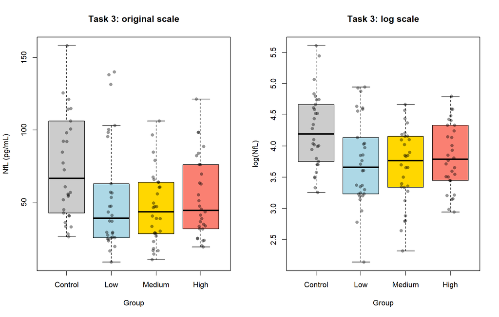

```r
# 3.2 VISUALISE ORIGINAL AND LOG SCALES

dose_colours <- c("grey80", "lightblue", "gold", "salmon")

par(mfrow = c(1, 2))

boxplot(
  NfL ~ Group, data = t3,
  outline = FALSE, col = dose_colours,
  main = "Task 3: original scale",
  ylab = "NfL (pg/mL)"
)

stripchart(
  NfL ~ Group, data = t3,
  vertical = TRUE, method = "jitter",
  add = TRUE, pch = 16,
  col = rgb(0, 0, 0, 0.4)
)

boxplot(
  log(NfL) ~ Group, data = t3,
  outline = FALSE, col = dose_colours,
  main = "Task 3: log scale",
  ylab = "log(NfL)"
)

stripchart(
  log(NfL) ~ Group, data = t3,
  vertical = TRUE, method = "jitter",
  add = TRUE, pch = 16,
  col = rgb(0, 0, 0, 0.4)
)
```

```r
par(mfrow = c(1, 1))

# The original data are right-skewed.
# The log scale improves symmetry and supports proportional interpretation.
```

## 3.3 Global comparison: linear model and ANOVA

Use a global F-test to ask whether all four mean log(NfL) values could be equal.

```r
# 3.3 GLOBAL COMPARISON: LINEAR MODEL AND ANOVA

dose_model <- lm(log(NfL) ~ Group, data = t3)

anova(dose_model)
```

```
Analysis of Variance Table

Response: log(NfL)
           Df Sum Sq Mean Sq F value  Pr(>F)
Group       3  5.973 1.99109  5.3908 0.00165 **
Residuals 116 42.845 0.36935
---
Signif. codes:  0 '***' 0.001 '**' 0.01 '*' 0.05 '.' 0.1 ' ' 1
```

```r
# Y = log(NfL).
# X = Group, a categorical predictor with four levels.
# Control is the reference group.
#
# OUTPUT: F(3, 116) = 5.3908; p = 0.001650.
#
# Global H0: all four population means of log(NfL) are equal.
# There is evidence that at least one mean differs.
# This does not identify which groups differ.
# It also does not imply that every pair differs.
```

## 3.4 Check model assumptions

Inspect residual normality and the variance pattern across the four groups.

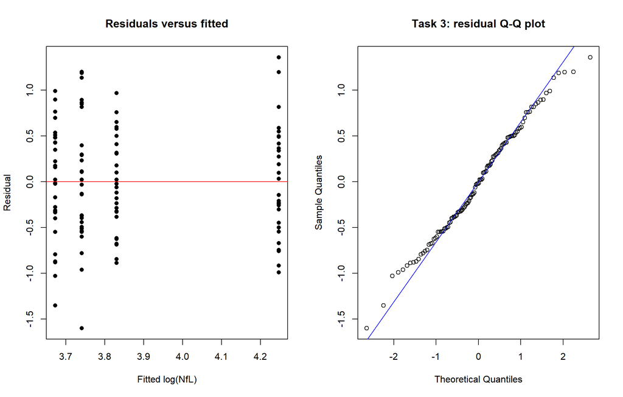

```r
# 3.4 CHECK MODEL ASSUMPTIONS

par(mfrow = c(1, 2))

plot(
  fitted(dose_model),
  residuals(dose_model),
  pch = 16,
  xlab = "Fitted log(NfL)",
  ylab = "Residual",
  main = "Residuals versus fitted"
)

abline(h = 0, col = "red")

qqnorm(residuals(dose_model), main = "Task 3: residual Q-Q plot")
qqline(residuals(dose_model), col = "blue")
```

```r
par(mfrow = c(1, 1))

tapply(log(t3$NfL), t3$Group, sd)
```

```
  Control       Low    Medium      High
0.6009543 0.6937209 0.5994858 0.5249961
```

```r
# OUTPUT:
# Control = 0.601; Low = 0.694; Medium = 0.599; High = 0.525.
#
# Ordinary ANOVA assumes common residual variance and approximately normal
# errors within groups. These SDs are reasonably similar; inspect the plots too.
#
# Four vertical bands in the residual plot are expected:
# the model gives one fitted mean to each of the four groups.
```

## 3.5 Planned comparisons with Holm correction

Compare each planned dose with Control while controlling multiplicity using Holm.

```r
# 3.5 PLANNED COMPARISONS WITH HOLM CORRECTION

# Reuse Welch's test from Tasks 1 and 2.
# Holm controls the false-positive risk across the three planned comparisons.
# These comparisons were defined before inspecting their p-values.

control_log <- log(t3$NfL[t3$Group == "Control"])
low_log <- log(t3$NfL[t3$Group == "Low"])
medium_log <- log(t3$NfL[t3$Group == "Medium"])
high_log <- log(t3$NfL[t3$Group == "High"])

low_test <- t.test(low_log, control_log, var.equal = FALSE)
medium_test <- t.test(medium_log, control_log, var.equal = FALSE)
high_test <- t.test(high_log, control_log, var.equal = FALSE)

# The dose is always the first argument.
# Exponentiating the difference therefore gives Dose/Control.

dose_results <- data.frame(
  Dose = c("Low", "Medium", "High"),

  Ratio = exp(c(
    low_test$estimate[1] - low_test$estimate[2],
    medium_test$estimate[1] - medium_test$estimate[2],
    high_test$estimate[1] - high_test$estimate[2]
  )),

  CI95_lower = exp(c(
    low_test$conf.int[1],
    medium_test$conf.int[1],
    high_test$conf.int[1]
  )),

  CI95_upper = exp(c(
    low_test$conf.int[2],
    medium_test$conf.int[2],
    high_test$conf.int[2]
  )),

  p_value = c(
    low_test$p.value,
    medium_test$p.value,
    high_test$p.value
  )
)

dose_results$p_Holm <- p.adjust(dose_results$p_value, method = "holm")

dose_results
```

```
    Dose     Ratio CI95_lower CI95_upper      p_value      p_Holm
1    Low 0.6029149  0.4310406  0.8433228 0.0037876005 0.007575201
2 Medium 0.5632391  0.4130156  0.7681023 0.0004749498 0.001424849
3   High 0.6594450  0.4925797  0.8828371 0.0059466838 0.007575201
```

```r
# KEY OUTPUTS:
# Dose      Ratio      Individual 95% CI       Raw p       Holm p
# Low       0.6029     [0.4310, 0.8433]         0.003788     0.007575
# Medium    0.5632     [0.4130, 0.7681]         0.000475     0.001425
# High      0.6594     [0.4926, 0.8828]         0.005947     0.007575
#
# Use the Holm-adjusted p-values for decisions across the three comparisons.
# Holm remains valid when the comparisons share a control group.
# The displayed CIs are individual 95% intervals:
# p.adjust() adjusts p-values, not confidence intervals.
#
# ANOVA and these comparisons answer related questions using the same data.
# They are not independent replications.
#
# FINAL TASK 3 STATEMENT:
# "All three doses showed lower geometric-mean NfL than Control after Holm
# adjustment (all adjusted p < 0.01). Estimated reductions were 39.7% for Low,
# 43.7% for Medium and 34.1% for High.
# The pattern does not show a simple monotonic dose-response relationship.
# Although Medium had the lowest estimate, these comparisons do not establish
# that it is superior to the other active doses.
# Lower NfL alone does not establish clinical benefit."


# ============================================================================
```

**Key conclusion:** The global ANOVA found evidence that at least one mean log(NfL) differed. Low, Medium and High all had lower geometric-mean NfL than Control after Holm adjustment. Medium had the lowest point estimate, but the analysis did not establish superiority over the other doses.

# Task 4 - Clinical outcomes

**Research focus:** How does ordinal clinical response vary by treatment, and how is it related to NfL?

## 4.1 Import and order the categories

Represent the clinical outcome as ordered categories and identify missing responses.

```r
# 4.1 IMPORT AND ORDER THE CATEGORIES

t4 <- read.csv("T4_data.csv", row.names = 1)

t4$Group <- factor(
  t4$Treatment,
  levels = c(0, 1, 2, 3),
  labels = c("Control", "Low", "Medium", "High")
)

response_levels <- c(
  "Asymptomatic",
  "No to slight symptoms",
  "Moderate disability",
  "Moderate to severe disability",
  "Severe disability"
)

t4$Response <- factor(
  t4$Response,
  levels = response_levels,
  ordered = TRUE
)

str(t4)
```

```
'data.frame':   120 obs. of  4 variables:
 $ ID       : int  1 2 3 4 5 6 7 8 9 10 ...
 $ Treatment: int  0 0 0 0 0 0 0 0 0 0 ...
 $ Response : Ord.factor w/ 5 levels "Asymptomatic"<..: 5 1 5 5 5 2 5 NA 5 4 ...
 $ Group    : Factor w/ 4 levels "Control","Low",..: 1 1 1 1 1 1 1 1 1 1 ...
```

```r
table(t4$Group)
```

```
Control     Low  Medium    High
     30      30      30      30
```

```r
table(t4$Response, useNA = "ifany")
```

```
                 Asymptomatic         No to slight symptoms
                            4                             8
          Moderate disability Moderate to severe disability
                           38                            25
            Severe disability                          <NA>
                           43                             2
```

```r
colSums(is.na(t4))
```

```
       ID Treatment  Response     Group
        0         0         2         0
```

```r
anyDuplicated(t4$ID)
```

```
[1] 0
```

```r
t4[is.na(t4$Response), c("ID", "Group")]
```

```
   ID   Group
8   8 Control
98 98    High
```

```r
# OUTPUT: 120 participants, 30 per arm; no repeated IDs.
# Missing responses: ID 8 in Control and ID 98 in High.
#
# Observed category counts:
# Asymptomatic = 4.
# No/slight symptoms = 8.
# Moderate disability = 38.
# Moderate/severe disability = 25.
# Severe disability = 43.
# Missing = 2.
#
# Keep missing responses as NA.
# Clinical-response plots use the 118 observed responses.
```

## 4.2 Frequency and percentage tables

Calculate counts and percentages within each treatment arm.

```r
# 4.2 FREQUENCY AND PERCENTAGE TABLES

# Rows = response categories; columns = treatment groups.
response_counts <- table(t4$Response, t4$Group)

response_counts
```

```
                                Control Low Medium High
  Asymptomatic                        1   1      1    1
  No to slight symptoms               1   1      3    3
  Moderate disability                 8  13     10    7
  Moderate to severe disability       3   8      7    7
  Severe disability                  16   7      9   11
```

```r
colSums(response_counts)
```

```
Control     Low  Medium    High
     29      30      30      29
```

```r
# OUTPUT denominators: Control = 29; Low = 30; Medium = 30; High = 29.
# table() excludes missing responses by default.

response_percent <- 100 * prop.table(response_counts, margin = 2)

round(response_percent, 1)
```

```
                                Control  Low Medium High
  Asymptomatic                      3.4  3.3    3.3  3.4
  No to slight symptoms             3.4  3.3   10.0 10.3
  Moderate disability              27.6 43.3   33.3 24.1
  Moderate to severe disability    10.3 26.7   23.3 24.1
  Severe disability                55.2 23.3   30.0 37.9
```

```r
# margin = 2 calculates percentages within columns, meaning within each group.
#
# COUNTS: Control / Low / Medium / High
# Asymptomatic                  1 /  1 /  1 /  1
# No to slight symptoms         1 /  1 /  3 /  3
# Moderate disability           8 / 13 / 10 /  7
# Moderate to severe            3 /  8 /  7 /  7
# Severe disability            16 /  7 /  9 / 11
#
# Severe disability percentages:
# Control = 55.2%; Low = 23.3%; Medium = 30.0%; High = 37.9%.
```

## 4.3 Visualise clinical response by treatment

Display the complete ordinal response distribution across the four arms.

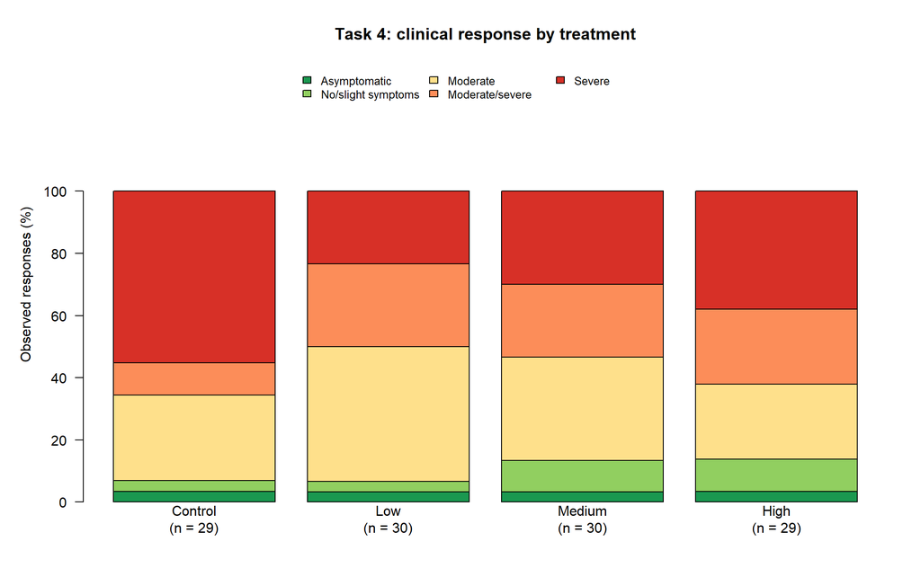

```r
# 4.3 VISUALISE CLINICAL RESPONSE BY TREATMENT

response_colours <- c(
  "#1A9850", "#91CF60", "#FEE08B", "#FC8D59", "#D73027"
)

par(mfrow = c(1, 1), mar = c(5, 5, 4, 2))

barplot(
  response_percent,
  col = response_colours,
  ylim = c(0, 140),
  yaxt = "n",
  ylab = "Observed responses (%)",
  names.arg = c(
    "Control\n(n = 29)",
    "Low\n(n = 30)",
    "Medium\n(n = 30)",
    "High\n(n = 29)"
  ),
  main = "Task 4: clinical response by treatment"
)

axis(2, at = seq(0, 100, 20), las = 1)

legend(
  "top",
  legend = c(
    "Asymptomatic", "No/slight symptoms",
    "Moderate", "Moderate/severe", "Severe"
  ),
  fill = response_colours,
  ncol = 3,
  bty = "n",
  cex = 0.8
)
```

```r
# Each bar represents 100% of available responses in that arm.
# The space above 100% is used only for the legend.
#
# Control has the largest proportion classified as Severe disability.
# The highest dose does not have the most favourable observed distribution.
# These are descriptive comparisons; no clinical-outcome hypothesis test
# has been performed.
```

## 4.4 Join Tasks 3 and 4 by participant ID

Join clinical response to the Task 3 biomarker by participant ID.

```r
# 4.4 JOIN TASKS 3 AND 4 BY PARTICIPANT ID

# Verify that each file contains unique IDs and the same set of participants.
stopifnot(
  anyDuplicated(t3$ID) == 0,
  anyDuplicated(t4$ID) == 0,
  setequal(t3$ID, t4$ID)
)

combined <- merge(
  t3,
  t4[, c("ID", "Treatment", "Response")],
  by = "ID"
)

nrow(combined)
```

```
[1] 120
```

```r
# OUTPUT: 120.

# merge() links the same person across files even if row orders differ.
# Do not attach clinical responses by row position.

group_names <- c("Control", "Low", "Medium", "High")

all(
  as.character(combined$Group) ==
    group_names[combined$Treatment + 1]
)
```

```
[1] TRUE
```

```r
# OUTPUT: TRUE; the treatment labels agree across the files.
# +1 converts treatment codes 0-3 into vector positions 1-4.

clinical <- combined[!is.na(combined$Response), ]

nrow(clinical)
```

```
[1] 118
```

```r
# OUTPUT: 118 complete records for clinical-response plots.
```

## 4.5 Relate NfL to clinical severity

Visualise how NfL varies across increasing levels of clinical severity.

```r
# 4.5 RELATE NfL TO CLINICAL SEVERITY

aggregate(NfL ~ Response, data = clinical, FUN = median)
```

```
                       Response     NfL
1                  Asymptomatic 30.5955
2         No to slight symptoms 34.1845
3           Moderate disability 40.8800
4 Moderate to severe disability 47.1310
5             Severe disability 54.0970
```

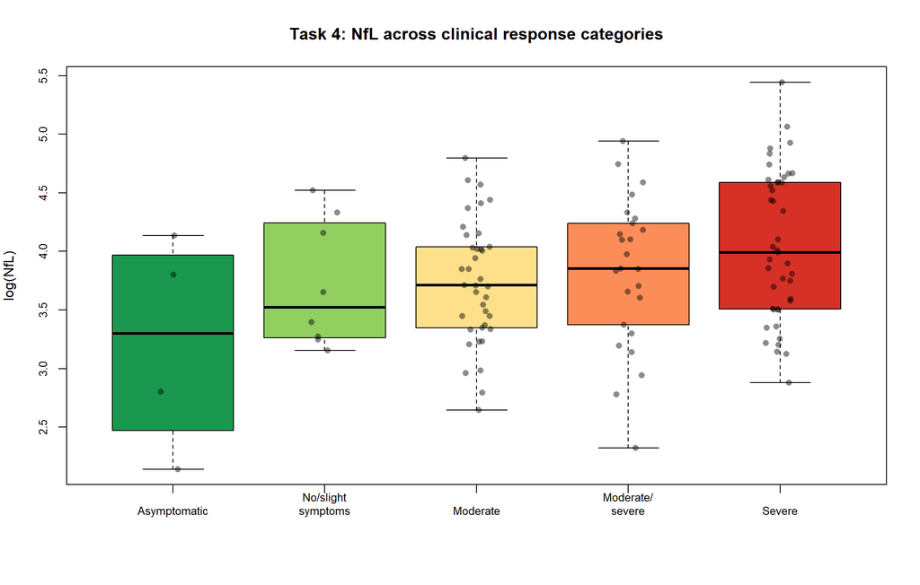

```r
# Median NfL in pg/mL, from least to most severe category:
# Asymptomatic                 30.5955
# No to slight symptoms        34.1845
# Moderate disability          40.8800
# Moderate to severe           47.1310
# Severe disability            54.0970
#
# Overall medians increase with severity.
# Individual observations still overlap substantially.

short_response <- c(
  "Asymptomatic",
  "No/slight\nsymptoms",
  "Moderate",
  "Moderate/\nsevere",
  "Severe"
)

par(mfrow = c(1, 1), mar = c(6, 4, 4, 2))

boxplot(
  log(NfL) ~ Response,
  data = clinical,
  names = short_response,
  outline = FALSE,
  col = response_colours,
  cex.axis = 0.8,
  ylab = "log(NfL)",
  xlab = "",
  main = "Task 4: NfL across clinical response categories"
)

stripchart(
  log(NfL) ~ Response,
  data = clinical,
  vertical = TRUE,
  method = "jitter",
  add = TRUE,
  pch = 16,
  col = rgb(0, 0, 0, 0.45)
)
```

```r
# Individual points show the small category sizes:
# Asymptomatic contains only 4 participants and No/slight symptoms contains 8.
# Boxes alone would hide this information.
```

## 4.6 Inspect the association within each treatment arm

Check whether the overall biomarker-response pattern is also visible within each treatment arm.

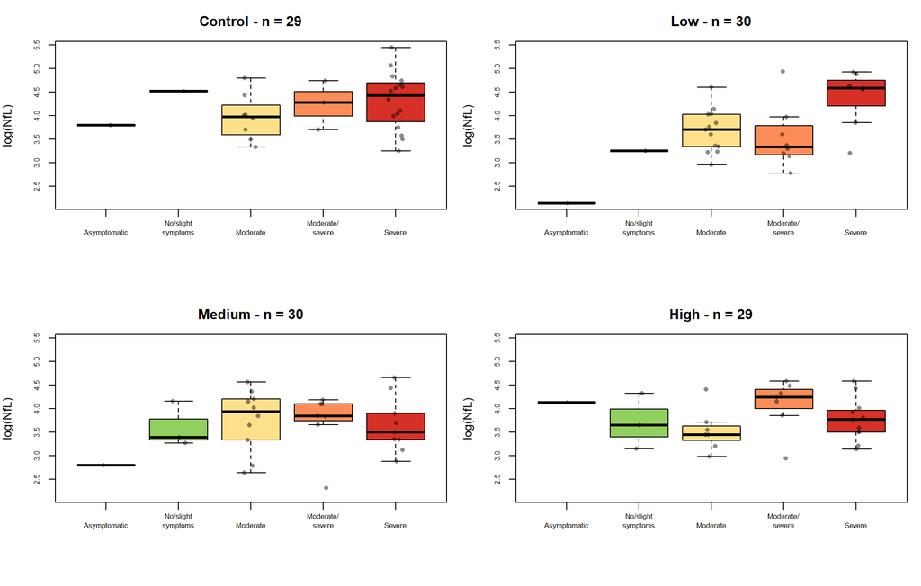

```r
# 4.6 INSPECT THE ASSOCIATION WITHIN EACH TREATMENT ARM

# Overall patterns can partly reflect differences between treatment groups.
# Repeat the same plot separately for each arm.

par(mfrow = c(2, 2), mar = c(6, 4, 3, 1))

for (group in levels(clinical$Group)) {

  group_data <- clinical[clinical$Group == group, ]

  boxplot(
    log(NfL) ~ Response,
    data = group_data,
    names = short_response,
    outline = FALSE,
    col = response_colours,
    cex.axis = 0.65,
    ylim = range(log(clinical$NfL)),
    ylab = "log(NfL)",
    xlab = "",
    main = paste(group, "- n =", nrow(group_data))
  )

  stripchart(
    log(NfL) ~ Response,
    data = group_data,
    vertical = TRUE,
    method = "jitter",
    add = TRUE,
    pch = 16,
    col = rgb(0, 0, 0, 0.45)
  )
}
```

```r
par(mfrow = c(1, 1), mar = c(5.1, 4.1, 4.1, 2.1))

# The same y-axis range makes panels comparable.
# Within-arm patterns are variable and some categories contain very few patients.
# An overall association need not be equally strong within every treatment arm.
#
# Task 4 asks for visual exploration, so a formal ordinal model is not needed.
#
# FINAL TASK 4 STATEMENT:
# "Severe disability was more frequent in Control (55.2%) than in the
# treatment arms (23.3-37.9%) among observed responses.
# Across all arms, median NfL increased with clinical severity, although
# biomarker values overlapped and within-arm patterns were variable.
# These findings are descriptive and exploratory.
# Two missing responses and small category sizes limit interpretation.
# The visual associations do not establish causation, treatment efficacy
# on clinical outcomes, or NfL as a validated surrogate."


# If you uncommented pdf() at the top, also uncomment the following line:
# dev.off()
```

[output not shown]

[output not shown]

**Key conclusion:** Severe disability was observed most frequently in Control. Across all arms, median NfL increased with clinical severity, but observations overlapped and within-arm patterns were variable. The visual association does not establish causation or clinical efficacy.